# (Loan Data from Prosper)

## Bivariate Exploration

Relationship between two numeric variables

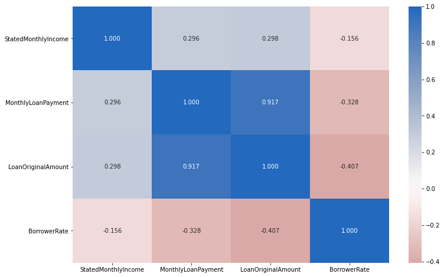

From the visual, the loan original amount is highly corelated with the monthly loan payment. This means that the monthly loan payment is highly dependent on the amount of loan granted

Relationship between Quantitative & Categorical variables

[figure not shown]

From the visual, we saw that the borrowers in the lowest income range(1 - 24,999 dollars) had the highest raate than other income range

## Multivariate Exploration

> Create plots of three or more variables to investigate your data even further. Make sure that your investigations are justified, and follow from your work in the previous sections.

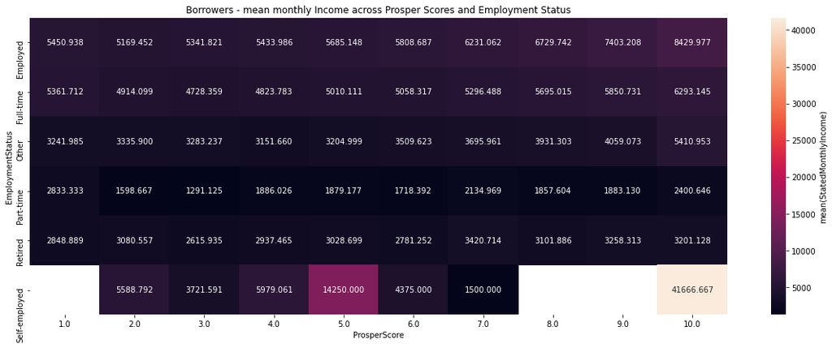

From the visual, Self employed borrowers with prosper score rating 10 had the highest stated monthly income

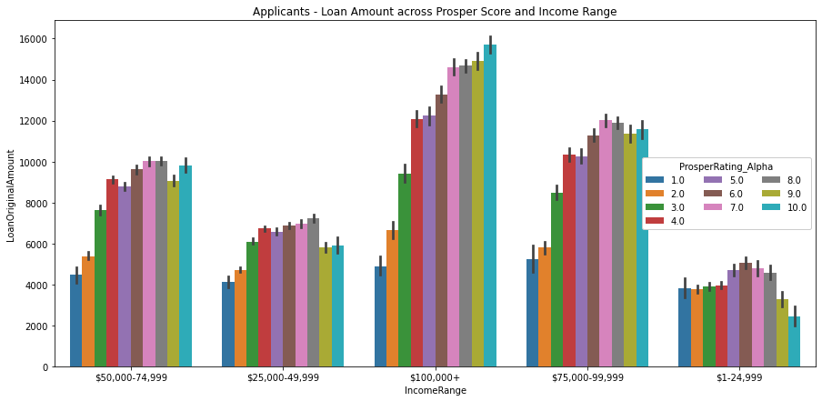

from the visual, the Prosper Score 10 increased as the income range increased. this means that people with high income range that apply for high loan original amount are most likely to have prosper score 10 from the visual,borrower from the(100,000 dollar) income range wwith a Prosper Score of 10 applied for the highest Loan Original Amount